# Survival Analysis

Jinfei Li

2021/12/8

## K-M Curve and Simple Parametric Distribution

### Data Summary

Data can be downloaded from [here](https://www.kaggle.com/taimurzahid/survival-regression-analysis-to-predict-churn/data), in the dataset, there is no entry age, which is exist in real case, so I added entry_age = 0 for all observations. Entry age is the client’s age (or loan age) when we start recording the records history.

The dataset samples are as below, where tenure is age, Churn is target variable, entry_age is the control of entry-age, customerID is ID, all other variables are covariate variables.

| customerID | gender | SeniorCitizen | Partner | Dependents | tenure | PhoneService | MultipleLines | InternetService | OnlineSecurity | OnlineBackup | DeviceProtection |
| --- | --- | --- | --- | --- | --- | --- | --- | --- | --- | --- | --- |
| 7590-VHVEG | Female | 0 | Yes | No | 1 | No | No phone service | DSL | No | Yes | No |
| 5575-GNVDE | Male | 0 | No | No | 34 | Yes | No | DSL | Yes | No | Yes |
| 3668-QPYBK | Male | 0 | No | No | 2 | Yes | No | DSL | Yes | Yes | No |

| TechSupport | StreamingTV | StreamingMovies | Contract | PaperlessBilling | PaymentMethod | MonthlyCharges | TotalCharges | Churn | entry_age |
| --- | --- | --- | --- | --- | --- | --- | --- | --- | --- |
| No | No | No | Month-to-month | Yes | Electronic check | 29.85 | 29.85 | 0 | 0 |
| No | No | No | One year | No | Mailed check | 56.95 | 1889.50 | 0 | 0 |
| No | No | No | Month-to-month | Yes | Mailed check | 53.85 | 108.15 | 1 | 0 |

### Parametric Method – Simple Distribution

Fit parametric distribution with no covariates:

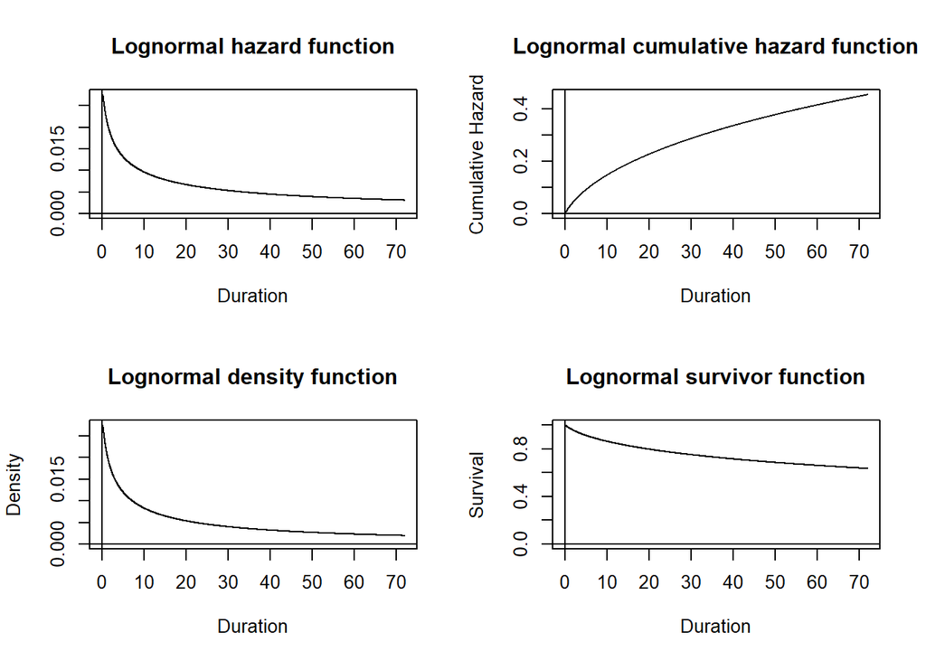

```r
exp.1 = flexsurvreg(Surv(entry_age, tenure, Churn, type='counting')~1
                    , data=training
                    , dist = 'exp')
lognormal.1 = aftreg(Surv(entry_age, tenure, Churn, type='counting')~1
                    , data=training
                    , dist = 'lognormal')
weibull.1 = aftreg(Surv(entry_age, tenure, Churn, type='counting')~1
                    , data=training
                    , dist = 'weibull')
loglog.1 = aftreg(Surv(entry_age, tenure, Churn, type='counting')~1
                    , data=training
                    , dist = 'loglogistic')
plot(lognormal.1)
```

Fit parametric distribution with variable “PhoneService”:

```r
lognormal.2 = aftreg(Surv(entry_age, tenure, Churn, type='counting')~strata(PhoneService)
                    , data=training
                    , dist = 'lognormal')
weibull.2 = aftreg(Surv(entry_age, tenure, Churn, type='counting')~strata(PhoneService)
                    , data=training
                    , dist = 'weibull')
loglog.2 = aftreg(Surv(entry_age, tenure, Churn, type='counting')~strata(PhoneService)
                    , data=training
                    , dist = 'loglogistic')
```

Check AIC for different models above:

No Covariates Distribution AIC

| weibreg.AIC | lognormal.AIC | loglogistic.AIC | exponential.AIC |
| --- | --- | --- | --- |
| 14592.52 | 14507.64 | 14579.3 | 14985.07 |

With Covariates Distribution AIC

| weibreg.AIC | lognormal.AIC | loglogistic.AIC |
| --- | --- | --- |
| 14589.82 | 14505.32 | 14576.64 |

Get distribution parameters and some survival functions:

```r
t = c(1:100)
# No-covariate-Weibull-distribution
shape = exp(weibull.1$coefficients[2])
scale = exp(weibull.1$coefficients[1])
s.weibull = exp(-((1/scale)*t)^shape)

# With-covariate-weibull-distrition
shape.1 = exp(weibull.2$coefficients[2])
scale.1 = exp(weibull.2$coefficients[1])
shape.2 = exp(weibull.2$coefficients[4])
scale.2 = exp(weibull.2$coefficients[3])
s.weibull.1 = exp(-((1/scale.1)*t)^shape.1)
s.weibull.2 = exp(-((1/scale.2)*t)^shape.2)

# No-covariate-lognormal-distribution
mu = lognormal.1$coefficients[1]
sigma = exp(lognormal.1$coefficients[2])

# No-covariates-loglog-distribution
alpha = exp(loglog.1$coefficients[1])
beta = exp(loglog.1$coefficients[2])
s.loglog = 1/(1+(t/alpha)^beta)

# Exponential-distribution
s.exp = exp(-exp(exp.1$coefficients)*t)
```

Get baseline survival rate and generate plot:

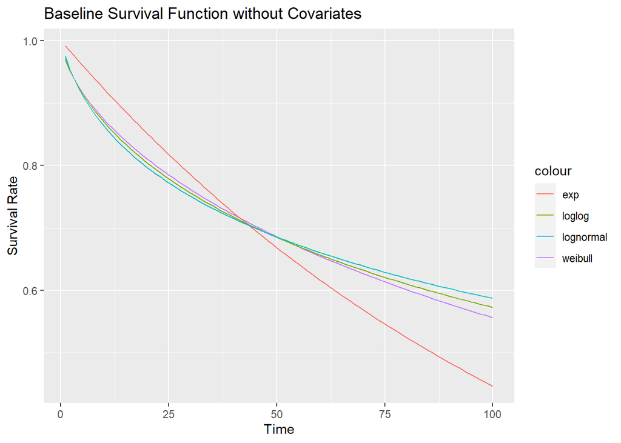

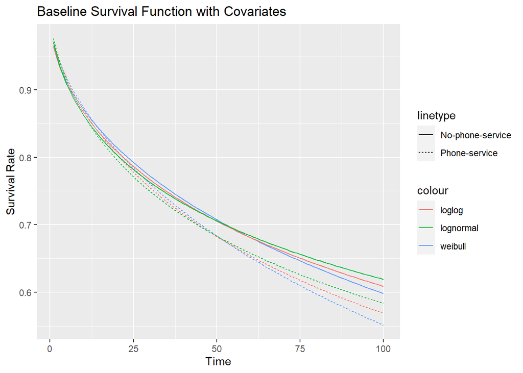

Check assumption of distribution

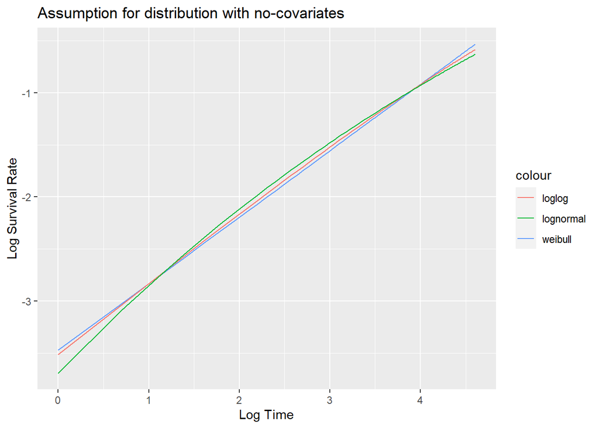

### KM Curve / CoxPH Model / Log Rank Test

**Log Rank Test:**

```r
survival::survdiff(survival::Surv(tenure, Churn)~ PhoneService, data = training)
```

```
## Call:
## survival::survdiff(formula = survival::Surv(tenure, Churn) ~
##     PhoneService, data = training)
##
##                     N Observed Expected (O-E)^2/E (O-E)^2/V
## PhoneService=No   491      119      127    0.4905     0.554
## PhoneService=Yes 4432     1168     1160    0.0536     0.554
##
##  Chisq= 0.6  on 1 degrees of freedom, p= 0.5
```

If the p-value here is non-significant, that means we have to stick with the null hypothesis which says that there is no difference in the survival probabilities of both groups for each group.

**KM Curve**

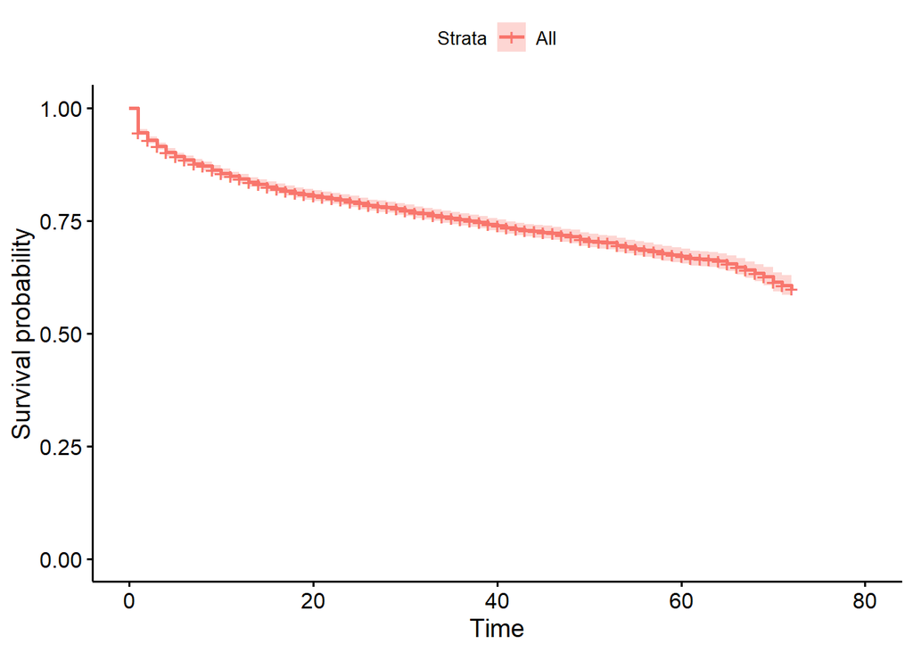

```r
kmcurve = survfit(Surv(entry_age, tenure, Churn) ~ 1, data = training)
ggsurvplot(kmcurve, data = training, pval = TRUE)
```

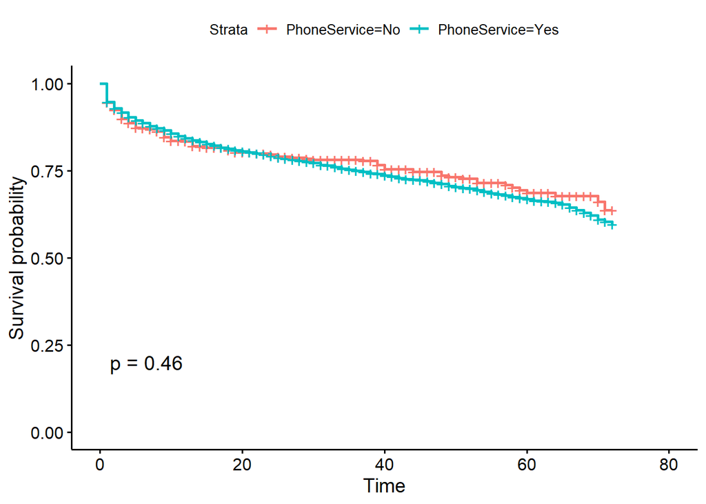

```r
kmcurve.2 = survfit(Surv(tenure, Churn) ~ PhoneService, data = training)
ggsurvplot(kmcurve.2, data = training, pval = TRUE)
```

**Cox PH Model** Cox-PH model code example can be found from [here](http://www.sthda.com/english/wiki/cox-proportional-hazards-model)

```r
base.coxph = coxph(Surv(entry_age, tenure, Churn) ~ PhoneService+gender+Dependents+Contract,
                   data = training, x=TRUE, y=TRUE)
base.hazard = basehaz(base.coxph)
base.km = exp(-base.hazard$hazard)
summary(base.coxph)
```

```
## Call:
## coxph(formula = Surv(entry_age, tenure, Churn) ~ PhoneService +
##     gender + Dependents + Contract, data = training, x = TRUE,
##     y = TRUE)
##
##   n= 4923, number of events= 1287
##
##                      coef exp(coef) se(coef)       z Pr(>|z|)
## PhoneServiceYes   0.12385   1.13184  0.09630   1.286    0.198
## genderMale       -0.08099   0.92220  0.05581  -1.451    0.147
## DependentsYes    -0.37950   0.68420  0.07330  -5.177 2.25e-07 ***
## ContractOne year -2.17153   0.11400  0.10229 -21.228  < 2e-16 ***
## ContractTwo year -4.14746   0.01580  0.18920 -21.921  < 2e-16 ***
## ---
## Signif. codes:  0 '***' 0.001 '**' 0.01 '*' 0.05 '.' 0.1 ' ' 1
##
##                  exp(coef) exp(-coef) lower .95 upper .95
## PhoneServiceYes     1.1318     0.8835   0.93716    1.3670
## genderMale          0.9222     1.0844   0.82665    1.0288
## DependentsYes       0.6842     1.4616   0.59264    0.7899
## ContractOne year    0.1140     8.7717   0.09329    0.1393
## ContractTwo year    0.0158    63.2731   0.01091    0.0229
##
## Concordance= 0.789  (se = 0.005 )
## Likelihood ratio test= 1828  on 5 df,   p=<2e-16
## Wald test            = 905.7  on 5 df,   p=<2e-16
## Score (logrank) test = 1625  on 5 df,   p=<2e-16
```

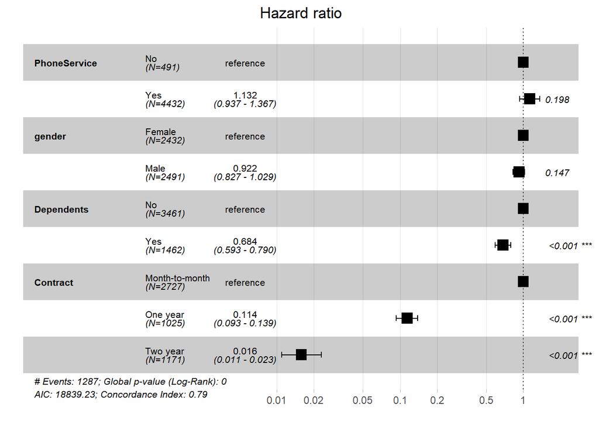

```r
ggforest(base.coxph, data = training)
```

### Survival Tree

```r
library(ranger)
streefit = ranger(Surv(tenure, Churn) ~ PhoneService+gender+Dependents+Contract,
                  data = training,
                  importance = 'permutation',
                  mtry=2,
                  verbose=TRUE,
                  num.trees=50,
                  write.forest = TRUE,
                  splitrule = 'extratrees',
                  seed = 43)
sort(streefit$variable.importance)
```

```
##  PhoneService        gender    Dependents      Contract
## -0.0009442608 -0.0001733648  0.0123174663  0.2445688386
```

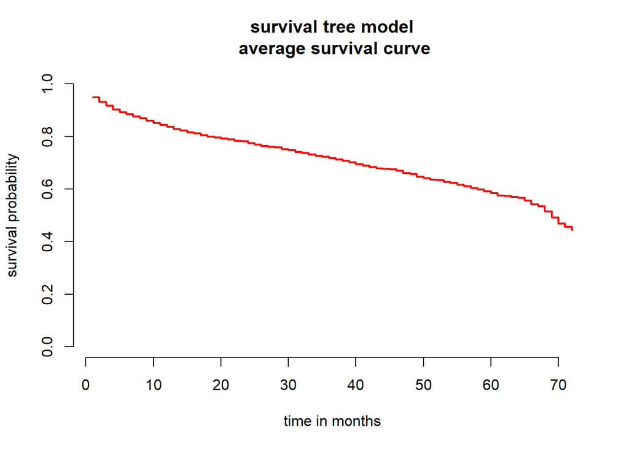

```r
death_times = streefit$unique.death.times
surv_prob = data.frame(streefit$survival)
avg_prob = sapply(surv_prob, mean)
plot(death_times,
     avg_prob,
     type = 's',
     ylim = c(0,1),
     col = 'red',
     lwd = 2,
     bty = 'n',
     ylab = 'survival probability',
     xlab = 'time in months',
     main = 'survival tree model\n average survival curve')
```

```r
treeInfo(streefit)
```

```
##    nodeID leftChild rightChild splitvarID splitvarName splitval terminal
## 1       0         1          2          3     Contract      1,2    FALSE
## 2       1         3          4          1       gender        1    FALSE
## 3       2         5          6          3     Contract        1    FALSE
## 4       3         7          8          2   Dependents        2    FALSE
## 5       4         9         10          2   Dependents        2    FALSE
## 6       5        11         12          0 PhoneService        2    FALSE
## 7       6        13         14          2   Dependents        2    FALSE
## 8       7        NA         NA         NA         <NA>     <NA>     TRUE
## 9       8        15         16          0 PhoneService        1    FALSE
## 10      9        NA         NA         NA         <NA>     <NA>     TRUE
## 11     10        17         18          0 PhoneService        1    FALSE
## 12     11        19         20          1       gender        2    FALSE
## 13     12        NA         NA         NA         <NA>     <NA>     TRUE
## 14     13        21         22          1       gender        2    FALSE
```

[output cut: 17 more lines]

```r
library(randomForestSRC)
rsf1 <- rfsrc(Surv(tenure, Churn)~PhoneService+gender+Dependents+Contract,
              data=training,ntree=15,forest=TRUE)
```

[**C-index**](https://search.r-project.org/CRAN/refmans/pec/html/cindex.html)

```r
library(pec)
A1  <- pec::cindex(list("Cox X1"=base.coxph,
                        "RSF"=rsf1),
                   formula=Surv(tenure, Churn)~1,
                   data=testing,
                   eval.times=seq(1,70,5))
print(A1)
```

```
##
## The c-index for right censored event times
##
## Prediction models:
##
## Cox X1    RSF
## Cox X1    RSF
##
## Right-censored response of a survival model
##
## No.Observations: 2109
##
## Pattern:
##                 Freq
##  event          582
##  right.censored 1527
##
## Censoring model for IPCW: marginal model (Kaplan-Meier for censoring distribution)
##
## No data splitting: either apparent or independent test sample performance
##
## Estimated C-index in %
##
## $AppCindex
##        time=1 time=6 time=11 time=16 time=21 time=26 time=31 time=36 time=41
## Cox X1   75.2   76.9    78.1    78.8    78.7    79.0    79.2    79.6    79.8
## RSF      74.7   77.2    77.8    78.8    78.7    78.7    79.4    79.8    80.0
##        time=46 time=51 time=56 time=61 time=66
## Cox X1    80.0    80.3    80.2    80.0    80.6
## RSF       80.1    80.5    80.0    79.5    78.4
```

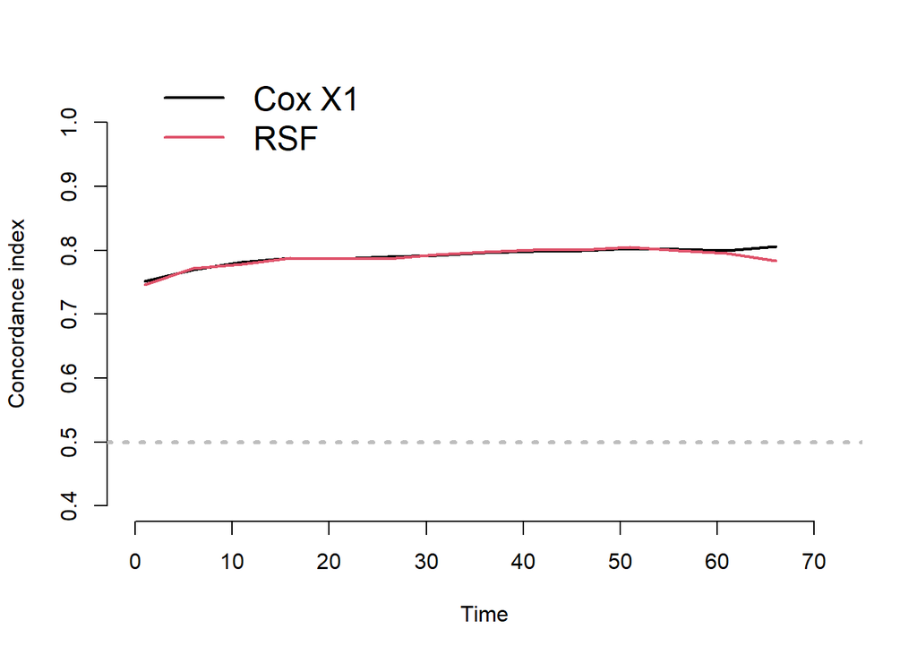

```r
plot(A1)
```

### Reference:

- https://medium.com/codex/survival-analysis-part-ii-ddbbae048d3f
- https://amunategui.github.io/survival-ensembles/